# Data Science and Business Analytics

### Important features of the final model

We shall deploy with the model giving the best F1 score on the test data which is the tuned XGBoost classifier with default parameters(xgb_tuned)

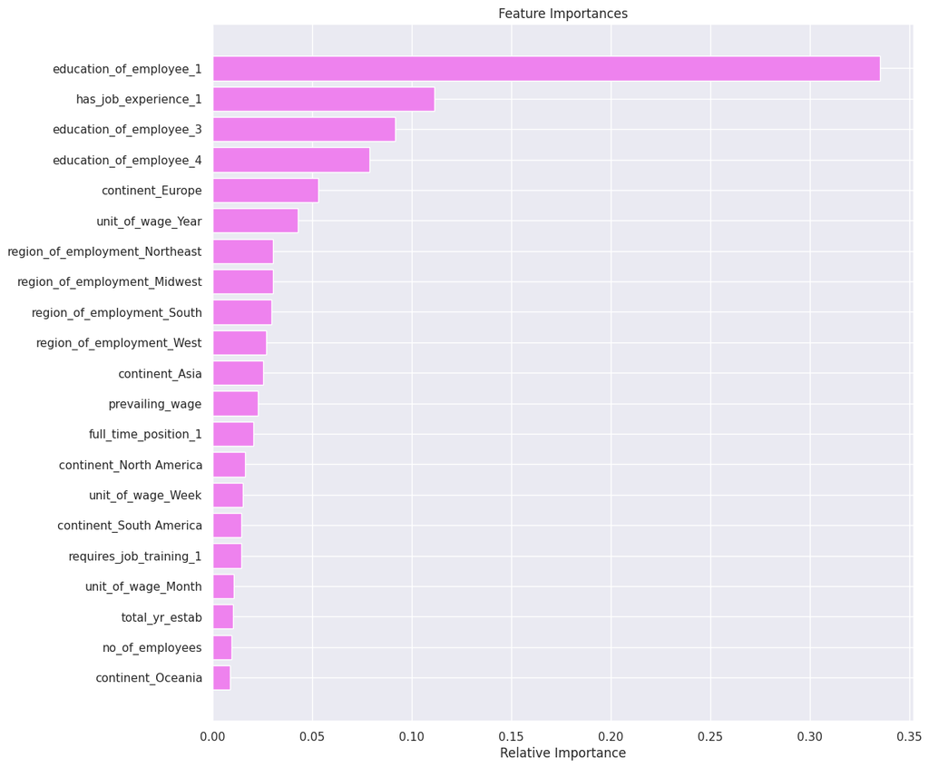

```python
feature_names = X_train.columns
importances = xgb_tuned.feature_importances_
indices = np.argsort(importances)

plt.figure(figsize=(12, 12))
plt.title("Feature Importances")
plt.barh(range(len(indices)), importances[indices], color="violet", align="center")
plt.yticks(range(len(indices)), [feature_names[i] for i in indices])
plt.xlabel("Relative Importance")
plt.show()
```

**Observations**

- Employee level of education was found to be the most important attribute influencing US visa certifications, followed by other important attributes such as prior job experience, unit_of_wage, continent employee belongs to and region of employment choice in the US.
- as per in the EDA section as well, unit of wage is an important feature /attribute that can improve the model's accuracy in predicting the likelihood of visa approval.

## **Business Insights and Recommendations**

### *EDA Insights*

Trend (EDA) Observation with regards to H1B Visa certification in the USA :

1. *Education* does have a significant impact on visa certification. We can observe that the higher the level of education received, the higher the number of visa applications certified. The percentage of certified visa applications is highest for applicants with a Doctorate degree (87.23%) followed by Master's (78.63%) and Bachelor's (62.21%).
2. *Having work experience* seems to have a positive impact on visa certification. Among applicants with work experience, 74.48% were certified and 25.52% were denied. However, among applicants without work experience, only 56.13% were certified and 43.87% were denied. We could improve the dataset with more quality information to give better results. Recommendations are given below.
3. A large percentage of visa applicants, about 88%, do not require *job training*. This again contributes to the visa certification and complements the above point as well. Skilled and experienced foreign workers in their chosen field would potentially save US employers time and money in terms of training and onboarding.
4. *Unit_of_wage* is an important attribute that can influence case statuses. Comparing the monthly and yearly prevailing wages in the data provided, we can see that the mean prevailing wage rate for Year is lower than the mean prevailing wage rate for Month. This suggests that applicants who are offered a monthly prevailing wage rate may have a higher chance of getting their visa approved as they are being offered a higher wage rate than applicants with a yearly wage rate.
5. In terms of *continents*, Asia had the highest number of visa applications (16,861 cases) compared to Europe (3,732 cases). However, Europe had the highest percentage of certified cases (79.23%) compared to Asia (65.31%). Generally, all continents had higher percentage of certified cases than denied cases, indicating that the majority of visa applications were successful.
6. Regarding the *analysis of regions* and visa case status, we can see that the Midwest region (75.53%, ) has the highest percentage of certifications among the regions, followed by the South (70.02%.).

**Some potential areas for further investigation which could be included in the dataset, and which can provide valuable insights in machine learning modeling and in OFLC's decision-making process when it comes to certifying or denying visa applications are:**

1. Type or quality of work experience: Instead of just having or not having work experience, you can consider including more specific information about the type or quality of work experience. For example, the industry of employment, length of employment, duration of work experience (length of time the applicant has worked in their previous roles as longer tenures may be viewed more positively by adjudicators).
2. Employer characteristics: The current dataset includes information about the employer's size, but other information such as the industry or location of the employer could also be included. Certain industries or geographic areas may have higher demand for certain types of visas.
3. Language proficiency: This could include information about the applicant's proficiency in English or other languages, which may be important for certain types of work or in certain locations.
4. Education field: The current dataset includes information about the employee's education level, but more detailed information about the field of study, their GPA could also be included as it would help provide a more nuanced understanding of an applicant's qualifications and improve the accuracy of visa certification predictions. Also certain fields of study may be more in demand than others, leading to higher approval rates for those with relevant degrees.
5. Country of origin: This could include information about the applicant's home country, as certain countries may have different visa requirements or be subject to different levels of scrutiny.

**By including these additional features in the dataset, the machine learning model may be better able to identify patterns and make more accurate predictions about visa certification. Reasons are :**

1. Feature selection: These breakdowns can help identify important features that can be used as inputs to the machine learning model to predict the likelihood of visa approval. For example, the prevailing wage rate for a particular occupation or industry can be an important predictor of visa approval, and in return can improve the model's accuracy.
2. Model training: By including these features in the dataset, the machine learning model can be trained on a more diverse set of data, which can improve its ability to generalize and make accurate predictions on new data.
3. Model evaluation: These breakdowns can be used to evaluate the performance of the machine learning model by comparing its predictions to the actual outcomes in different occupational, geographic, and industry contexts. This can help identify areas where the model may be overfitting or underfitting the data and suggest ways to improve its accuracy.

However, it's important to keep in mind that including too many features could lead to overfitting, so it's important to carefully select the most relevant features and regularly evaluate the model's performance.